# Part 2 - Cluster Annotation

### ### plot the UMAP and TSNE side by side to visualize clusters

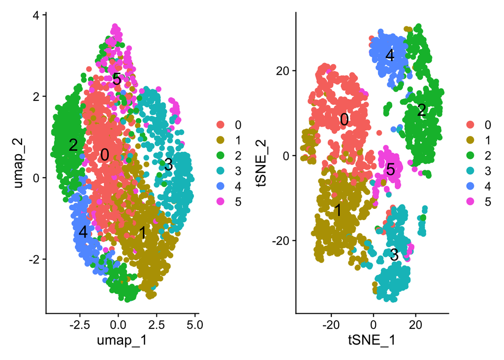

```r
p1<- UMAPPlot(pbmc, reduction = "umap", label = TRUE, pt.size = 2 ,label.size = 6)
p2<- TSNEPlot(pbmc, reduction = "tsne", label = TRUE, pt.size = 2 ,label.size = 6)
p1+p2
```

```r
pbmc.markers <- FindAllMarkers(pbmc, only.pos = TRUE)
```

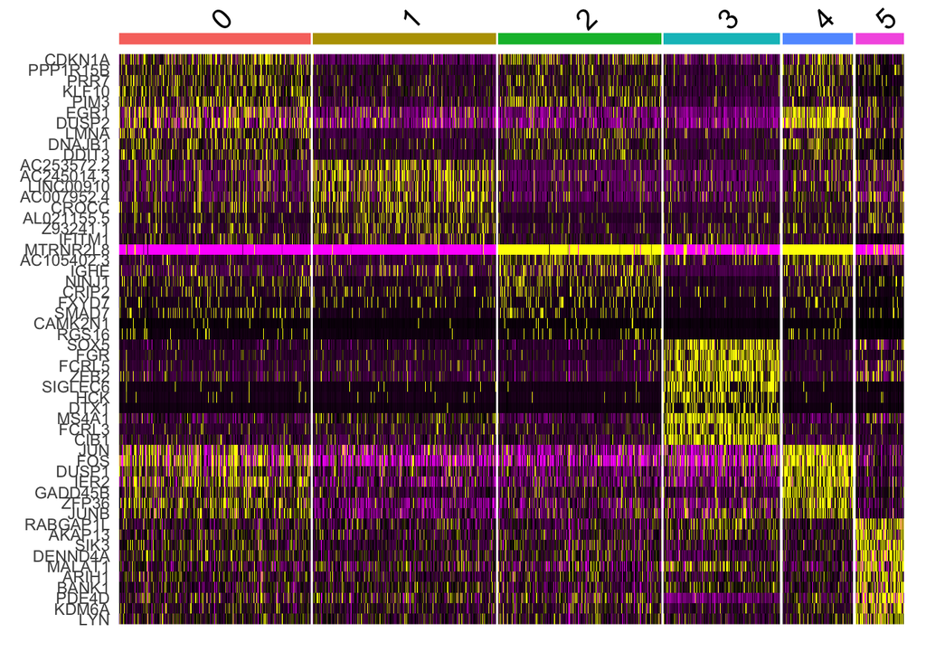

```r
pbmc.markers %>%
    group_by(cluster) %>%
    dplyr::filter(avg_log2FC > 1) %>%
    slice_head(n = 10) %>%
    ungroup() -> top10
DoHeatmap(pbmc, features = top10$gene) + NoLegend()
```

### load the HPCA reference dataset

```r
### load HPCA immune reference
hpca.ref <- celldex::HumanPrimaryCellAtlasData()
```

```
## see ?celldex and browseVignettes('celldex') for documentation
```

```
## loading from cache
```

```
## see ?celldex and browseVignettes('celldex') for documentation
```

```
## loading from cache
```

```r
# Let’s convert our Seurat object to single cell experiment (SCE) for convenience. After this, using SingleR becomes very easy:
sce <- as.SingleCellExperiment(DietSeurat(pbmc))
sce
```

```
## class: SingleCellExperiment
## dim: 15077 2456
## metadata(0):
## assays(2): counts logcounts
## rownames(15077): AL627309.1 LINC01409 ... AC233755.2 AC233755.1
## rowData names(0):
## colnames(2456): AAACCTGAGCCCAGCT-1 AAACCTGAGTGACTCT-1 ...
##   TTTGTCACAGGGATTG-1 TTTGTCATCAGCATGT-1
## colData names(12): orig.ident nCount_RNA ... seurat_clusters ident
## reducedDimNames(0):
## mainExpName: SCT
## altExpNames(1): RNA
```

```r
### Assign identity to clusters
hpca.fine <- SingleR(test = sce,assay.type.test = 1,ref = hpca.ref,labels = hpca.ref$label.fine, clusters=pbmc@meta.data$seurat_clusters)
hpca.ont <- SingleR(test = sce,assay.type.test = 1,ref = hpca.ref,labels = hpca.ref$label.ont, clusters=pbmc@meta.data$seurat_clusters)
print('DONE')
```

```
## [1] "DONE"
```

### View fine assignment

```r
table(hpca.fine$labels)
```

```
##
## B_cell:immature   B_cell:Memory
##               3               3
```

CLUSTER LABELS

### View ontology assignment

```r
table(hpca.ont$pruned.labels)
```

```
##
## CL:0000787 CL:0000816
##          3          3
```

CL:0000787 - memory B cell CL:0000816 - immature B cell

CLUSTER LABELS

### save metadata

```r
# write.csv(hpca.fine,"hpca_Bcell_cluster_annotation_fine.csv" )
# write.csv(hpca.ont,"hpca_B_cell_cluster_annotation_ont.csv" )

print('DONE')
```

```
## [1] "DONE"
```

Finally, let’s visualize the cluster-wise fine-grained annotations.

```r
pbmc.ont <-  RenameIdents(pbmc, `0` = "0 : Memory B cell", `1` = "1 : Immature B cell", `2` = "2 : Immature B cell", `3` = "3 : Memory B cell", `4` = "4 : Immature B cell", `5` = "5 : Memory B cell")
pbmc.final <-  RenameIdents(pbmc, `0` = "Memory B cell", `1` = "Immature B cell", `2` = "Immature B cell", `3` = "Memory B cell", `4` = "Immature B cell", `5` = "Memory B cell")
```

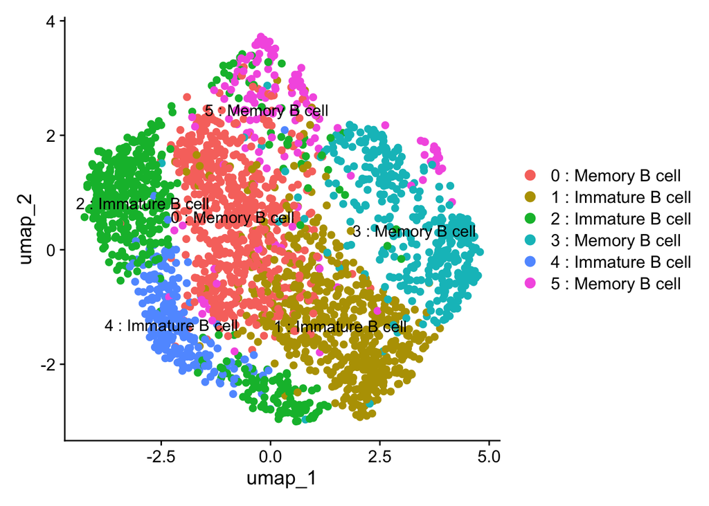

```r
UMAPPlot(pbmc.ont , reduction = 'umap' ,label = TRUE, pt.size = 2 ,label.size = 4)
```

visualize the B cell subtypes

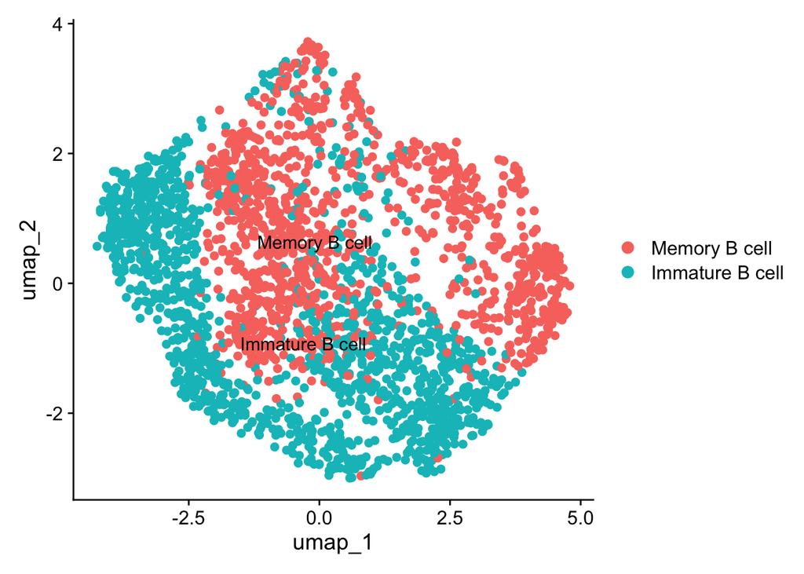

```r
UMAPPlot(pbmc.final, reduction = 'umap',  label = TRUE, pt.size = 2 ,label.size = 4)
```

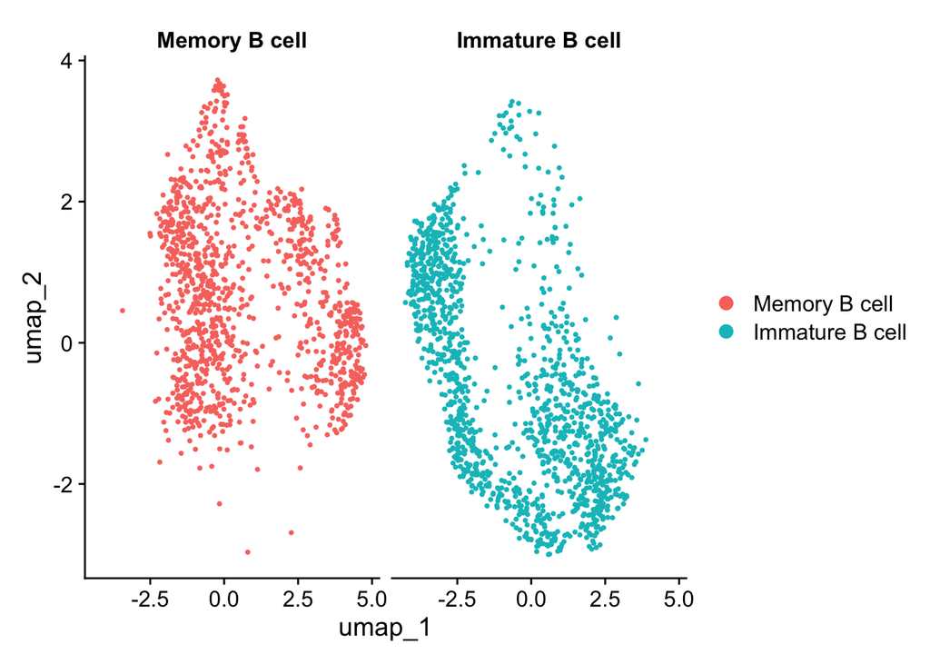

```r
DimPlot(object = pbmc.final, reduction = 'umap' , split.by = 'ident')
```

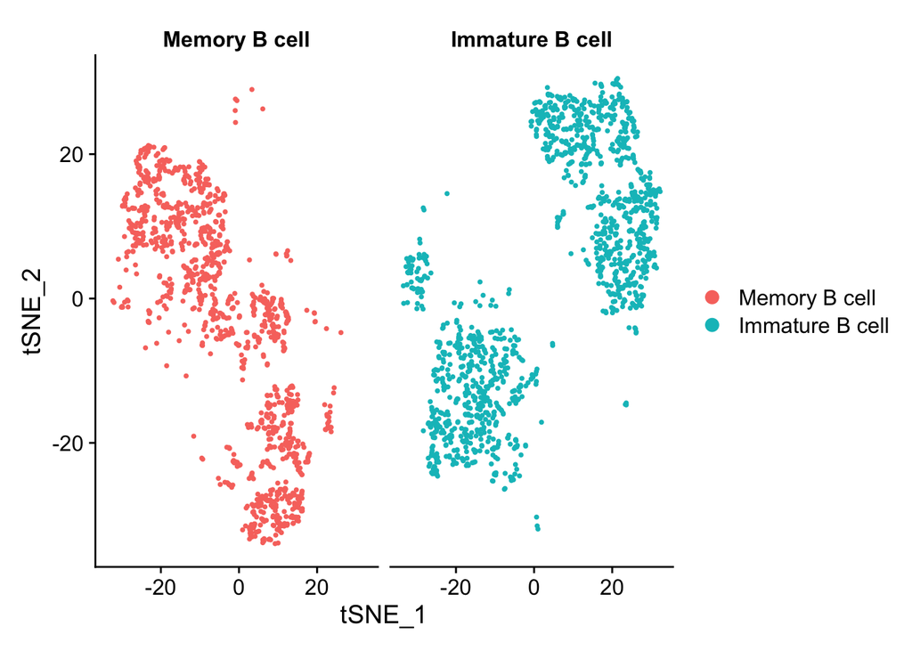

```r
DimPlot(object = pbmc.final, reduction = 'tsne' , split.by = 'ident')
```

For further validation, let’s explore using canonical Memory B cell markers https://www.rndsystems.com/research-area/b-cell-markers

B220/CD45R ,C1qR1/CD93, CD19, CD21, CD27/TNFRSF7, CD40/TNFRSF5, CD20, MHC class II (I-A/I-E), TACI/TNFRSF13B AIM2, CD20 , CD27, CD79A, IGD, JCHAIN, MS4A1

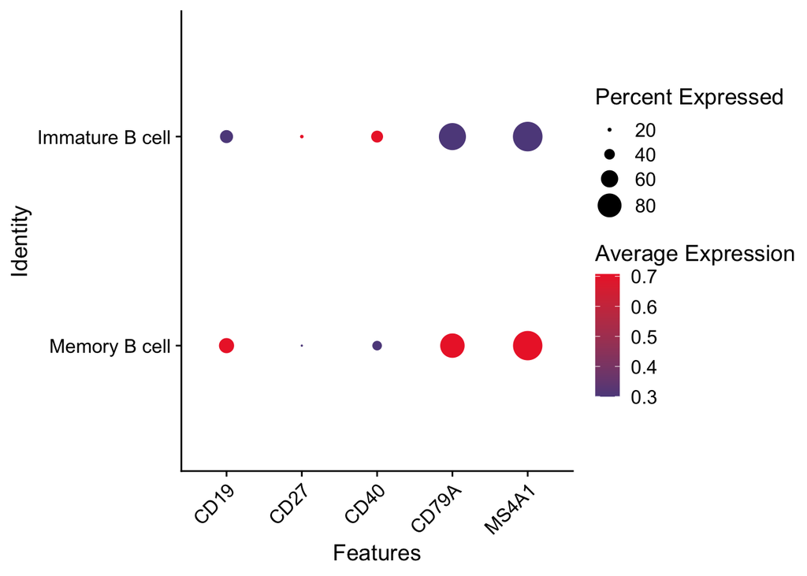

```r
features <- c('CD19', 'CD27', 'CD40' , 'CD79A' ,'MS4A1' )

DotPlot(pbmc.final, features = features, cols=c("#5F4B8BFF", "#ED2B33FF"), assay = "RNA", col.min = 0.3, col.max = 0.8, dot.min=0.12, dot.scale = 8, cluster.idents=F) + RotatedAxis()
```

feature plot of Memory B cell markers

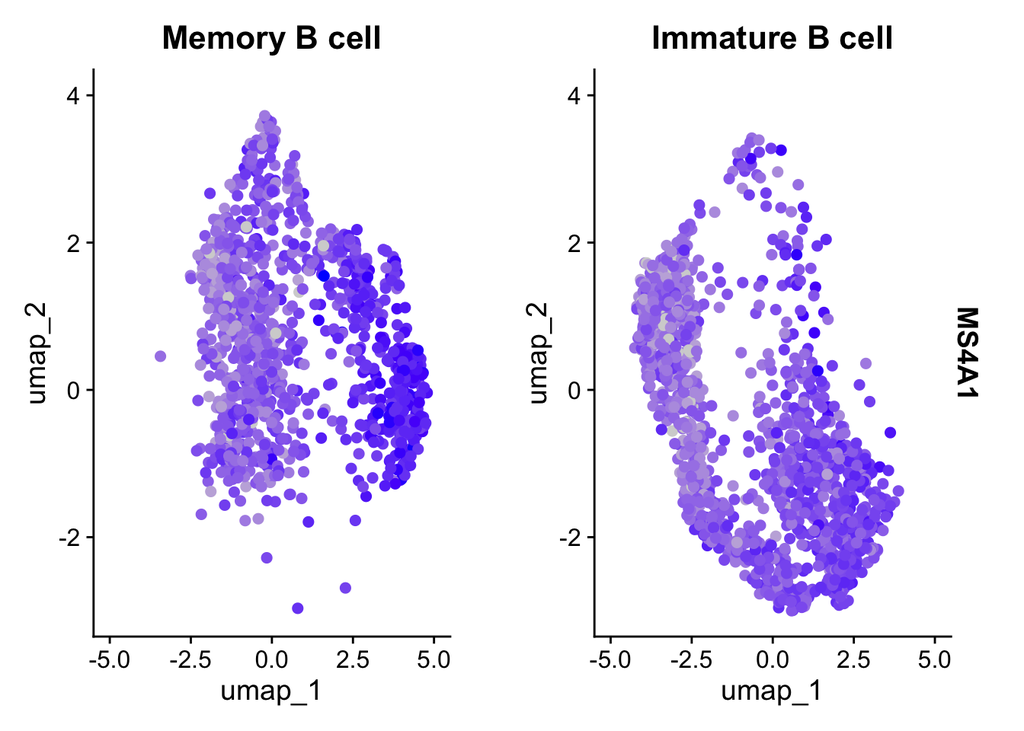

```r
FeaturePlot(object = pbmc.final, features = "MS4A1", pt.size = 2,  split.by = 'ident', keep.scale = 'feature')
```

Immature B cell markers retrieved from the CellMarker 2.0 databasee https://doi.org/10.1093/nar/gkac947 http://117.50.127.228/CellMarker/CellMarkerBrowse.jsp

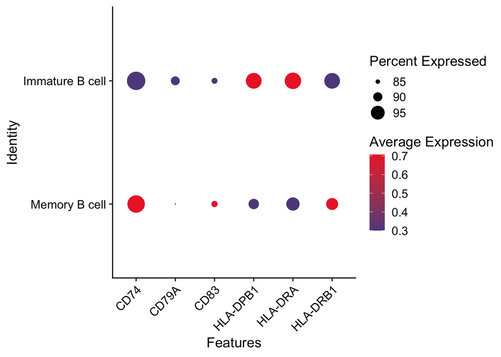

```r
features <- c('CD74' , 'CD79A' , 'CD83' , 'HLA-DPB1' , 'HLA-DRA' , 'HLA-DRB1')

DotPlot(pbmc.final, features = features, cols=c("#5F4B8BFF", "#ED2B33FF"), assay = "RNA", col.min = 0.3, col.max = 0.8, dot.min=0.12, dot.scale = 8,
        cluster.idents=F) + RotatedAxis()
```

feature plot of Immature B cell markers

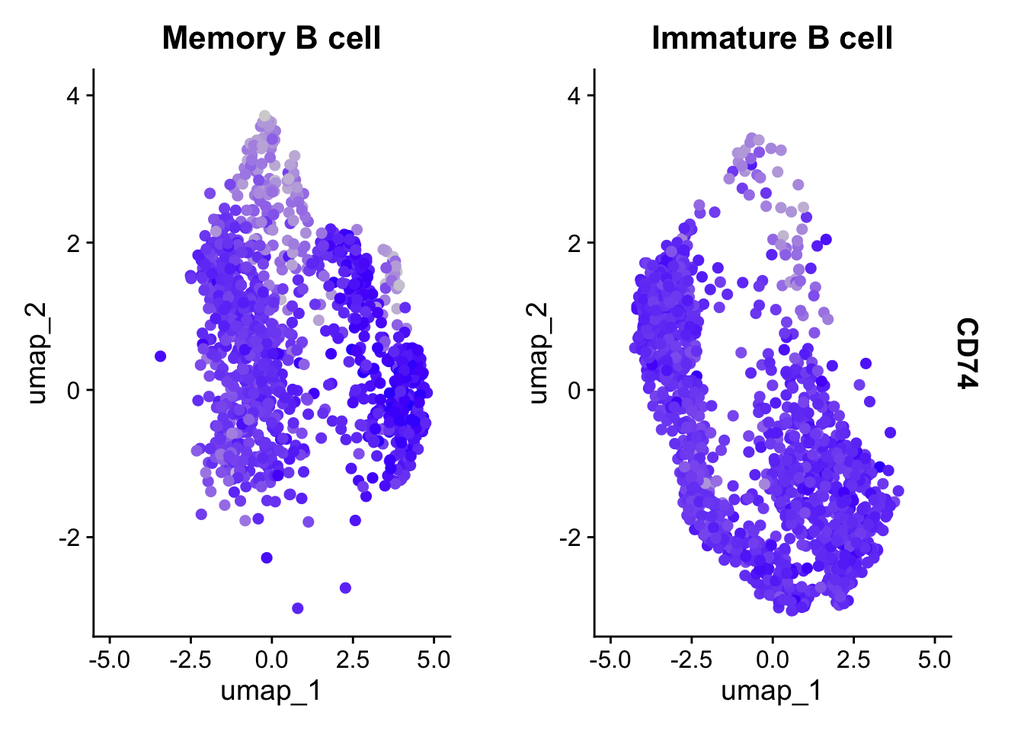

```r
FeaturePlot(object = pbmc.final, features = "CD74", pt.size = 2,  split.by = 'ident', keep.scale = 'feature')
```

### save object

```r
saveRDS(pbmc.final, "/Users/hawacoulibaly/Documents/GitHub/scHumanBcellFlu/data/pbmc_3k_annotated.RDS")
```